# Introduction to computational finance

## The Greeks

Like in the series 9, let an asset S be valuated at t = 0. Let be a put option having maturity T = 1 and strike price K = 120. The volatility is assumed to be constant (σ = 20%) over the lifespan of the put; the risk-free rate is r = 5%; the put is an European option. Using the Black-Scholes formula to valuate the put price: • Plot the evolution of the put price as a function of the initial assert price S0. • Plot the ∆ for this put. • Plot the Γ for this put. • Comment the graphs.

```
## [1] -712.8084
```

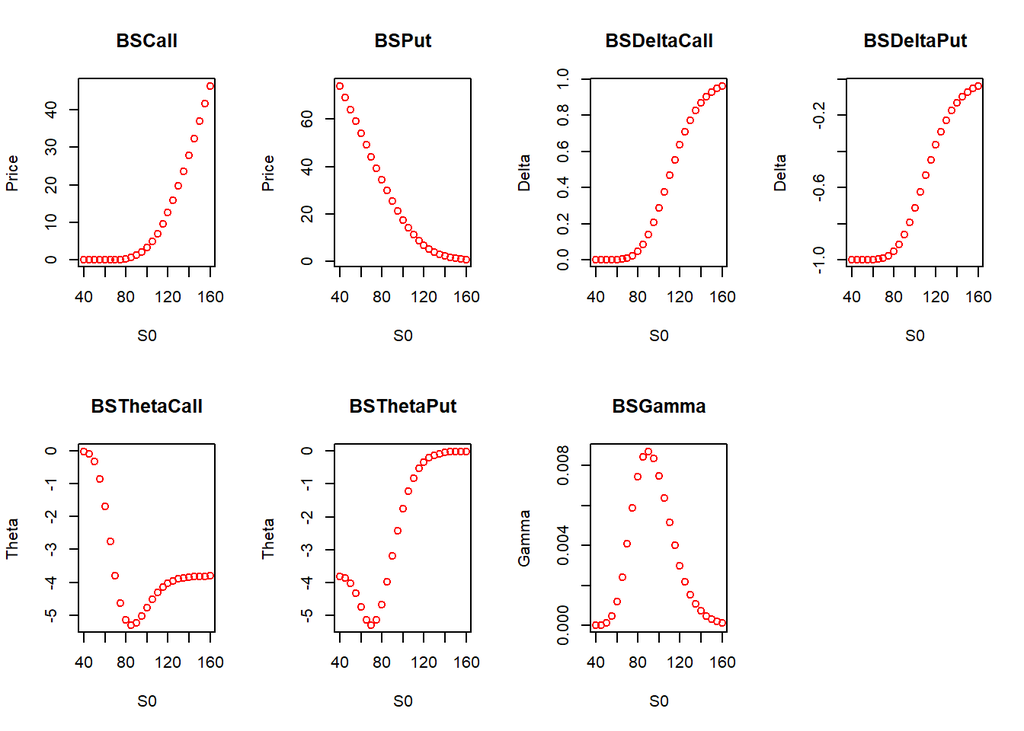

```r
BSCall <- function(S0=100, K=120, T=1, rf= 0.05, sigma=0.2){
  d1<- (log(S0/K)+(rf + sigma^2/2)*T)/(sqrt(T)*sigma)
  d2<- (log(S0/K)+(rf - sigma^2/2)*T)/(sqrt(T)*sigma)
  return (S0*pnorm(d1) - K * exp(-rf*T)*pnorm(d2))
}

BSPut <- function(S0=100, K=120, T=1, rf= 0.05, sigma=0.2){
  d1<- (log(S0/K)+(rf + sigma^2/2)*T)/(sqrt(T)*sigma)
  d2<- (log(S0/K)+(rf - sigma^2/2)*T)/(sqrt(T)*sigma)
  return (-S0*pnorm(-d1) + K * exp(-rf*T)*pnorm(-d2))
}

BSDeltaCall <- function(S0=100, K=120, T=1, rf= 0.05, sigma=0.2){
  d1<- (log(S0/K)+(rf + sigma^2/2)*T)/(sqrt(T)*sigma)
  return (pnorm(d1))
}

BSDeltaPut <- function(S0=100, K=120, T=1, rf= 0.05, sigma=0.2){
  d1<- (log(S0/K)+(rf + sigma^2/2)*T)/(sqrt(T)*sigma)
  return (-pnorm(-d1))
}

BSThetaCall <- function(S0=100, K=80, T=1, rf= 0.05, sigma=0.2){
  d1<- (log(S0/K)+(rf + sigma^2/2)*T)/(sqrt(T)*sigma)
  d2<- (log(S0/K)+(rf - sigma^2/2)*T)/(sqrt(T)*sigma)
  return (-S0*sigma*exp(-d1^2/2)/2/sqrt(T)/sqrt(2*pi)-rf*K*exp(-rf*T)*pnorm(d2))
}

BSThetaPut <- function(S0=100, K=80, T=1, rf= 0.05, sigma=0.2){
  d1<- (log(S0/K)+(rf + sigma^2/2)*T)/(sqrt(T)*sigma)
  d2<- (log(S0/K)+(rf - sigma^2/2)*T)/(sqrt(T)*sigma)
  return (-S0*sigma*exp(-d1^2/2)/2/sqrt(T)/sqrt(2*pi)-rf*K*exp(-rf*T)*pnorm(-d2))
}

BSGamma <- function(S0=100, K=100, T=1, rf= 0.05, sigma=0.2){
  d1<- (log(S0/K)+(rf + sigma^2/2)*T)/(sqrt(T)*sigma)
  return (1/S0/sigma/sqrt(T)*exp(-d1^2/2)/2/pi)
}


K= c(BSCall,BSPut,BSDeltaCall,BSDeltaPut,BSThetaCall,BSThetaPut,BSGamma)
K2= c('BSCall','BSPut','BSDeltaCall','BSDeltaPut','BSThetaCall','BSThetaPut','BSGamma')
YAXE=c('Price','Price','Delta','Delta','Theta','Theta','Gamma')
incr=1
par(mfrow=c(2,4))
for (i in K){
  dep<-seq(40,160,5)
  bin<-lapply(dep,function(x)i(S0=x))
  plot(dep,bin,col='red',xlab='S0',ylab=YAXE[incr],
       main= K2[incr] )
  incr =incr+1
}

BSDeltaPut(S0=100)*1000
```

Suppose that the asset price is S0 = 100, and we sell 1000 puts. • We want be ∆-neutralized, which position should we have?